# ENVX1002_Group_Project

# **-NOT THE FINAL DOCUMENT-**

# Outline

**EDA**

- What are the variables like.
- Central value and spread of variables.
- Distribution of data.

**Modelling**

1. Null and alternate hypotheses
2. Fit the model
3. check Assumptions
4. interpret model output. State the equation, state estimates and what they mean.
5. Interpret significance of model and predictors.
6. Interpret model fit statistics. Residual standard error, appropriate R2, plot regression line.
7. Statistical conclusion
8. Scientific conclusion.

## Checklist

- EDA - central tendency stats
- EDA - Distribution stats
- EDA - QQ plots and histograms
- Model - hypotheses, null and alternate
- Model - fit the model
- Model - Check assumptions
- Model - output equation
- Model - estimates and what they mean
- Model - interpret significance of model and predictors
- Model - Model fit statistics, R2, Residual SE, plot regression line
- Model - statistical and scientific conclusions.

# Now here’s the actually important stuff

Set up stuff:

```r
library(readr)
library(tidyverse)
library(modeest)
library(ggplot2)
```

```r
WHR_2023 <- read_csv("data/WHR_2023.csv")
gdp <- WHR_2023$gdp_per_capita
life <- WHR_2023$healthy_life_expectancy
happy <- WHR_2023$happiness_score
```

## EDA Section

Variable Description: Both GDP per capita and Healthy Life Expectancy are continuous, numerical variables.

There are no missing data points in GDP per capita. There is one missing data point in Healthy Life Expectancy. The missing data point is from the State of Palestine.

### Central tendency stats

**GDP:** Mean, median, mode.

```r
mean_gdp <- mean(gdp)
median_gdp <- median(gdp)
mode_gdp <- mfv(gdp)[1]
mean_gdp
```

```
[1] 1.406985
```

```r
median_gdp
```

```
[1] 1.449
```

```r
mode_gdp
```

```
[1] 0.914
```

Summary: Mean = 1.406985. Median = 1.449. Mode = 0.914.

**Healthy life expectancy:** Mean, median, mode.

```r
mean_life <- mean(life, na.rm = TRUE)
median_life <- median(life, na.rm = TRUE)
mode_life <- mfv(life, na_rm = TRUE)[1]
mean_life
```

```
[1] 0.3661765
```

```r
median_life
```

```
[1] 0.3895
```

```r
mode_life
```

```
[1] 0.389
```

Summary: Mean = 0.3661765. median = 0.3895, mode = 0.389.

**GDP:** Measures of Spread

```r
range_gdp <- range(gdp)
iqr_gdp <- IQR(gdp)
var_gdp <- var(gdp)
sd_gdp <- sd(gdp)
range_gdp
```

```
[1] 0.0 2.2
```

```r
iqr_gdp
```

```
[1] 0.699
```

```r
var_gdp
```

```
[1] 0.1874567
```

```r
sd_gdp
```

```
[1] 0.4329627
```

Summary: Range = 0 to 2.2. Interquartile range (IQR) = 0.699. Variance = 0.1874567. Standard Deviation (SD) = 0.4329627.

```r
# Standard error = population sd / sqrt(n) = 0.43 / sqrt(137)
se_gdp <- 0.43/sqrt(137)
se_gdp
```

```
[1] 0.03673738
```

Summary: Standard Error of GDP per capita = 0.03673738

**Life Expectancy** Measures of Spread

```r
range_life <- range(life, na.rm = TRUE)
iqr_life <- IQR(life, na.rm = TRUE)
var_life <- var(life, na.rm = TRUE)
sd_life <- sd(life, na.rm = TRUE)
range_life
```

```
[1] 0.000 0.702
```

```r
iqr_life
```

```
[1] 0.239
```

```r
var_life
```

```
[1] 0.0245521
```

```r
sd_life
```

```
[1] 0.1566911
```

Summary: Range = 0 to 0.702. Interquartile range (IQR) = 0.239. Variance = 0.0245521. Standard Deviation (SD) = 0.1566911.

```r
#Standard error = population sd / sqrt(n) = 0.16 / sqrt(136)
se_life <- 0.16/ sqrt(136)
se_life
```

```
[1] 0.01371989
```

Summary: Standard error of Life Expectancy = 0.01371989.

### Distribution Analysis

**GDP**

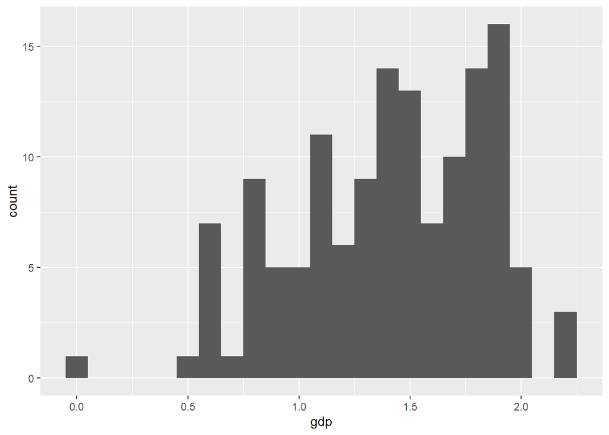

```r
ggplot(WHR_2023, aes(x = gdp))+
  geom_histogram(binwidth = 0.1)
```